# Instrumente Statistice pentru Finanțe

## 4.7 Ajustarea pozițiilor (*position adjustments*)

Fiecare strat geomentric *geom* prezintă, pe lângă o transformare statistică implicită, și o ajustare implicită a poziției care specifică un set de *reguli* privind modul în care componentele diferite ale graficului trebuie poziționate unele față de altele. Această poziționare implicită este vizibilă în special în cadrul funcției `geom_bar` atunci când aplicăm o variabilă diferită caracteristicii vizuale de colorare (e.g. `colour` sau `fill`).

De exemplu, să considerăm diagrama cu bare care ilustrează numărul de tări de pe fiecare continent folosind setul de date `gapminder_2018`. Putem colora barele folosind sau estetica `colour` sau estetica `fill` (de preferat).

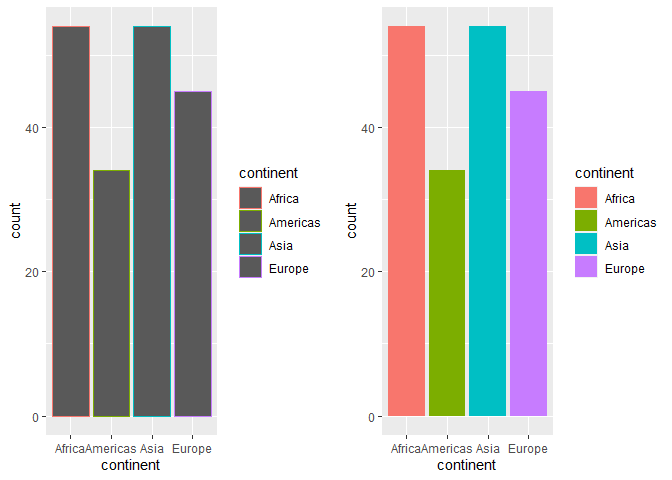

```r
gapminder_2018 %>%
  ggplot() +
  geom_bar(aes(x = continent, colour = continent))

gapminder_2018 %>%
  ggplot() +
  geom_bar(aes(x = continent, fill = continent))
```

Acum dacă colorăm diagrama cu bare de mai sus în raport cu nivelul de venit (conform Băncii Mondiale) obținem o diagramă cu bare suprapuse colorate în funcție de această varaibilă.

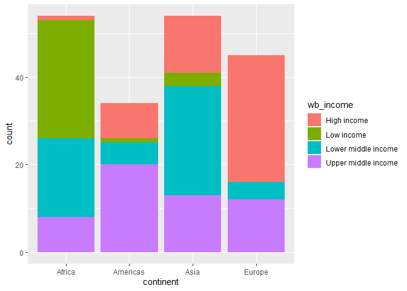

```r
gapminder_2018 %>%
  ggplot() +
  geom_bar(aes(x = continent, fill = wb_income))
```

Suprapunerea barelor (`stack`) în `geom_bar` (înălțimea dreptunghiurilor este proporțională cu valoarea lor) se face în mod automat prin ajustarea poziției specificate de argumentul `position` (default `position = "stack"`). Dacă nu se dorește suprapunerea barelor atunci se poate folosi una din următoarele ajustări: `identity`, `dodge` sau `fill`.

- `position = "identity"` - opțiunea impune plasarea fiecărui obiect exact unde se află în contextul figurii (nu este foarte folositoare atunci când trasăm diagrame cu bare dar este opțiunea de default pentru diagramele de împrăștiere)

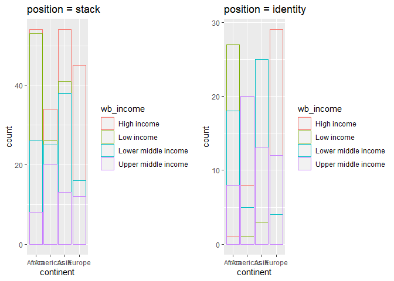

```r
gapminder_2018 %>%
  ggplot(aes(x = continent, colour = wb_income)) +
  geom_bar(position = "identity", fill = NA)
```

- `position = "fill"` - opțiunea este similară cu `stack`, suprapunând barele în așa fel încât înălțimea acestora să fie constantă (este de preferat atunci când dorim să comparăm proporții între grupuri)

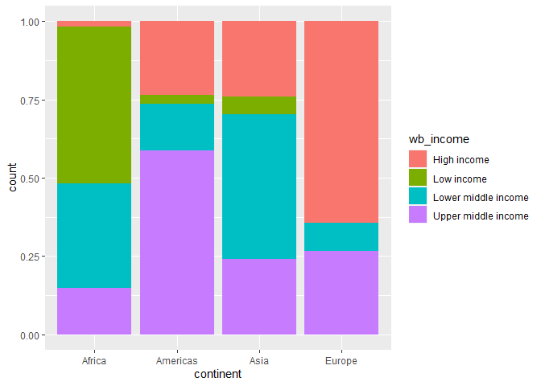

```r
gapminder_2018 %>%
  ggplot(aes(x = continent, fill = wb_income)) +
  geom_bar(position = "fill")
```

- `position = "dodge"` - opțiunea plasează obiectele unul lângă celălalt și permite astfel o mai bună comparare între valorile individuale

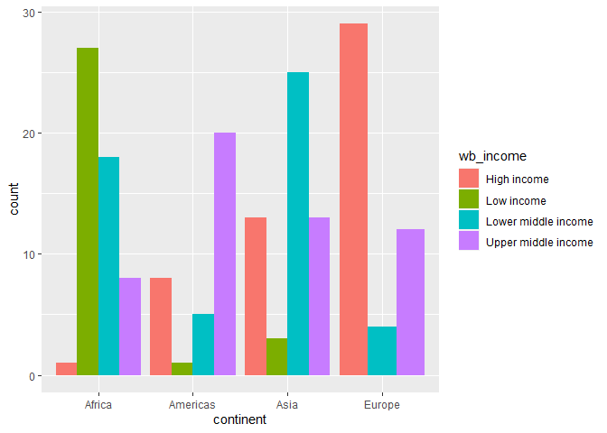

```r
gapminder_2018 %>%
  ggplot(aes(x = continent, fill = wb_income)) +
  geom_bar(position = "dodge")
```

Trebuie menționat că `geom_boxplot` are ca și poziționare implicită poziționarea `dodge` după cum se poate observa și din exemplul de mai jos.

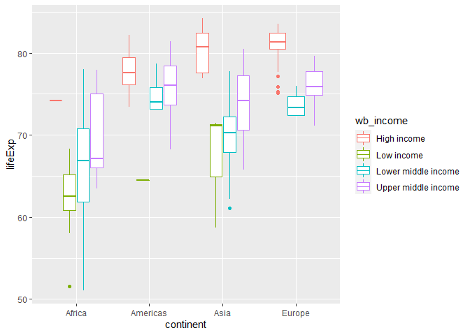

```r
# position dodge - comportament de default pentru boxplot
gapminder_2018 %>%
  ggplot(aes(x = continent, y = lifeExp)) +
  geom_boxplot(aes(colour = wb_income))
```

Tipurile de poziții prezentate mai sus se aplică în special diagramelor cu bare (sau boxplot-urilor) dar, trebuie menționat că pachetul `ggplot2` pune la dispoziție și trei metode de ajustare a pozițiilor în cazul punctelor: `position_nudge()` - asigură mutarea punctelor printr-o valoare fixată (default în cazul `geom_text()`); `position_jitter()` - adaugă poziției fiecărui punct un zgomot aleator pentru a dispersa un pic datele; `position_jitterdodge()` - permite separarea/evitarea (*dodge*) puntelor în interiorul grupurilor și apoi adaugă zgomot aleator pozițiilor.

Vom ilustra primele două ajustări de poziții în contextul setului de date `gapminder_all` în care afișăm pentru anii 1989, 2000 și 2018 speranța medie de viață pentru fiecare țară.

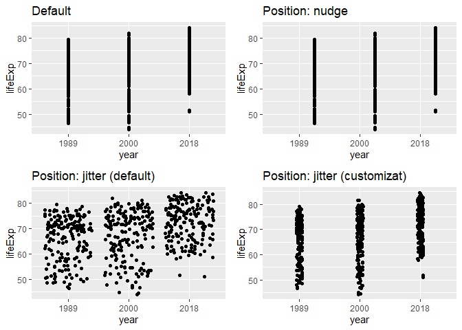

```r
# initial
gapminder_all %>%
  filter(year %in% c("1989", "2000", "2018")) %>%
  ggplot(aes(x = year, y = lifeExp)) +
  geom_point()

# position nundge
gapminder_all %>%
  filter(year %in% c("1989", "2000", "2018")) %>%
  ggplot(aes(x = year, y = lifeExp)) +
  geom_point(position = position_nudge(x = 0.25, y = 0))

# position jitter - default
gapminder_all %>%
  filter(year %in% c("1989", "2000", "2018")) %>%
  ggplot(aes(x = year, y = lifeExp)) +
  geom_point(position = "jitter")

#position jitter - cu specificatii
gapminder_all %>%
  filter(year %in% c("1989", "2000", "2018")) %>%
  ggplot(aes(x = year, y = lifeExp)) +
  geom_point(position = position_jitter(width = 0.05, height = 0.5))
```

Pentru mai multe informații referitoare la tipurile de ajustare a pozițiilor în obiectele grafice din `ggplot2` se poate consulta documentația fiecărei funcții `geom` sau se poate apela comanda

```r
help.search("position_", package = "ggplot2")
```

## 4.8 Sisteme de coordonate (*coordinate systems*)

Pachetul `ggplot2` pune la dispiziție și o serie de funcții care fac referire la sistemul de coordonate în care sunt trasate elementele grafice. Sistemele de coordonate sunt specificate prin funcții care încep prin `coord_` și sunt adăugate ca straturi la graficul existent. Pachetul dispune de mai multe sisteme de coordonate printre care enumerăm:

- `coord_cartesian` - sistemul cartezian care este și cel de default și în care trebuie specificare valorile pe x și y
- `coord_flip` - sistemul cartezian în care axele sunt schimbate între ele
- `coord_fixed` - un sistem cartezian care păstrează fixat aspectul (*aspect ratio* - numărul de unități pe axa y care corespund unei unități pe axa x) cu raportul de bază de 1
- `coord_polar` - sistemul de coordonate polar
- `coord_quickmap` - un sistem de coordonate care aproximează sistemul sferic al planeti în vederea trasării hărților

Folosind sistemul cartezian cu opțiunea `xlim` (respectiv `ylim`) putem vizualiza doar acea regiune a graficului care ne interesează (putem face zoom). Diferența majoră dintre utilizarea limitelor în interiorul funcției `coord_cartesian` și utilizarea limitelor în funcțiile de scală (e.g. `scale_x_continuous`) este că în primul caz utilizăm tot setul de date pe când în cel de al doilea caz sunt folosite doar observațiile care se află între limitele setate, toate celelalte puncte fiind excluse.

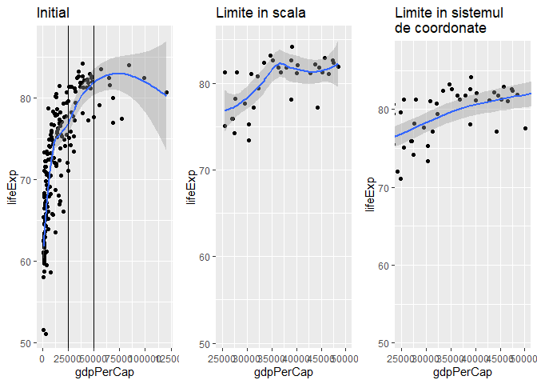

```r
# folosind scala - fitam curba de regresie pe datele ramase
ggplot(gapminder_2018, aes(x = gdpPerCap, y = lifeExp)) +
  geom_point() +
  geom_smooth() +
  scale_x_continuous(limits = c(25000, 50000))

# folosind sistemul de coordonate - fitam curba de regresie
# pe toate datele si evidentiem doar zona de interes
ggplot(gapminder_2018, aes(x = gdpPerCap, y = lifeExp)) +
  geom_point() +
  geom_smooth()+
  coord_cartesian(xlim = c(25000, 50000))
```

Sunt multe situațiile în care suntem interesați de valorile variabilei de pe axa x condiționate la variabila de pe axa y și în acest caz este recomandată schimbarea (întoarcerea) sistemului de coordonate prin apelarea funcției `coord_flip()`. De asemenea, o altă situație în care se recomandă rotirea coordonatelor cu 90 de grade este în cazul trasării unei diagrame cu bare sau a unui boxplot în funcție de o variabilă calitativă cu un număr mare de categorii sau cu categorii a căror denumire este lungă. Vom ilustra această transformare a sistemului de coordonate folosind diagrama cu bare pentru a evidenția numărul țărilor din setul de date `gapminder_2018` de pe fiecare continent.

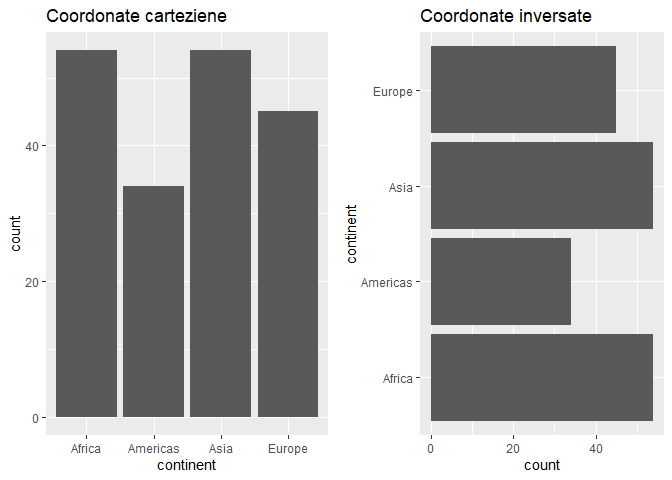

```r
# coordonate carteziene
gapminder_2018 %>%
  ggplot(aes(x = continent)) +
  geom_bar()

# coordonate flip
gapminder_2018 %>%
  ggplot(aes(x = continent)) +
  geom_bar() +
  coord_flip()
```

În mod similar putem vizualiza prin intermediul unui boxplor diferențele dintre duratele medii de viață de pe fiecare continent:

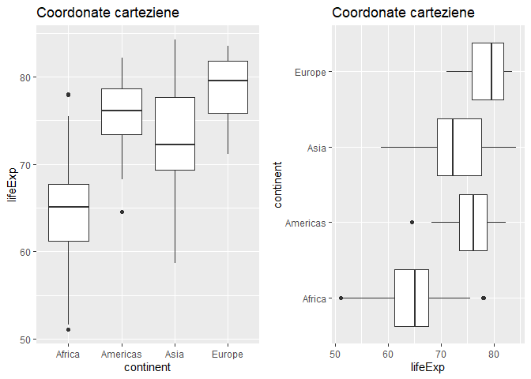

Un alt mod de vizualizare a datelor calitative (categoriale), frecvent utilizat în practică, este reprezentat de diagrama circulară (pie chart). Trebuie menționat că acest tip de grafic nu este recomandat având în vedere că oamenii tind să supraestimeze unghiurile mai mari de 90 de grade și să subestimeze unghiurile mai mici de 90 de grade astfel fiind dificilă compararea mărimii relative a două sectoare din diagrama circulară (Robbins 2013). Pentru a crea o diagramă circulară în `ggplot2` vom folosi transformarea în coordonate polare `coord_polar`. Ideea este de a pleca de la o diagramă cu bare suprapuse (*stacked barchart*) și apoi să o transpunem în coordonate polare.  
Figura de mai jos prezintă o diagramă circulară pentru proporția țărilor de pe fiecare continent care depășesc produsul intern brut median global.

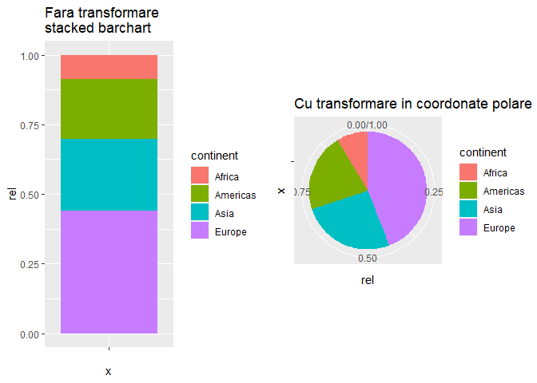

```r
gapminder_2018 %>%
  mutate(gdp_avg = median(gdpPerCap)) %>%
  filter(gdpPerCap > gdp_avg) %>%
  mutate(n_all = n()) %>%
  group_by(continent) %>%
  summarize(rel = n() / unique(n_all)) %>%
  ggplot(aes(x = "", y = rel)) +
  geom_col(aes(fill = continent)) +
  coord_polar("y")
```

Mai multe detalii despre sistemele de coordonate se pot găsi în lucrarea de referință (Wickham 2016).

## 4.9 Fațetare (*facets*)

Procesul de *fațetare* (*facets*) presupune divizarea unei figuri în subfiguri determinate de valorile unei variabile categoriale sau a mai multor variabile categoriale. Astfel, în cazul în care vorbim de o singură varaibilă, pentru fiecare categorie a variabilei este trasat un subgrafic. Pachetul `ggplot2` pune la dispoziție două funcții utile pentru a efectua această operație:

- `facet_wrap()` - folosită atunci când avem de-a face cu o singură varaibilă de grupare a datelor
- `facet_grid()` - folosită atunci când dorim secționarea datelor după două sau mai multe variabile

Spre exemplu, setul de date `gapminder_2018` conține informații referitoare la produsul intern brut ajustat (`gdpPerCap`) și speranța medie de viață (`lifeExp`) pentru mai mult de 180 de țări de pe patru continente (`continents`). Dacă dorim să vedem relația dintre cele două variabile în funcție de continent atunci una dintre variante ar fi să folosi estetica `colour` pentru a diferenția. O variantă alternativă, care uneori ilustrează mai clar diferențele, este de a subsecționa graficul în subgrafice ce corespund fiecărui continent folosind funcția `facet_grid()`.

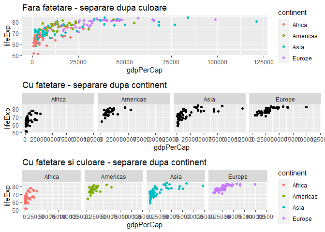

```r
ggplot(gapminder_2018, aes(x = gdpPerCap, y = lifeExp, colour = continent)) +
  geom_point()

ggplot(gapminder_2018, aes(x = gdpPerCap, y = lifeExp)) +
  geom_point() +
  facet_grid(.~continent)
```

În figura de mai sus am folosit `facet_grid` pentru a separa în subgrafice chiar dacă separarea s-a făcut în funcție de o singură variabilă (*continent*). Observăm că în apelarea funcției `facet_grid` (`?facet_grid`) am folosit simbolul `~` care separă variabila/variabilele din stânga (trasată/trasate de-a lungul liniilor) de cea/cele din dreapta (trasată/trasate pe coloane). Codul generic pentru funcția `facet_grid` este

```r
facet_grid([factor pentru linii] ~ [factor pentru coloane])
```

Pentru ilustrare să considerăm că ne dorim să investigăm relația dintre `gdpPerCap` și `lifeExp` în funcție de regiunea și nivelul de venit stabilite de Banca Mondială (variabilele `wb_region` și respectiv `wb_income`).

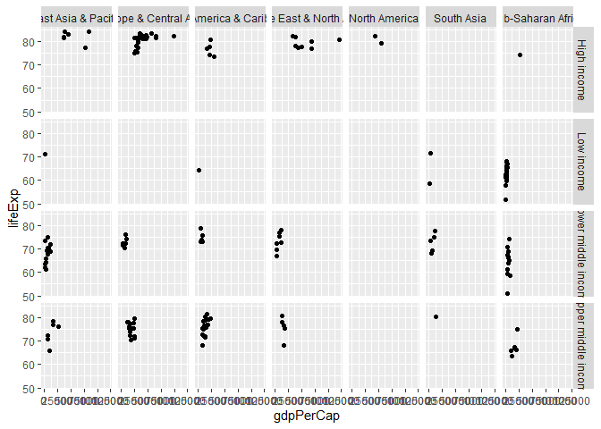

```r
ggplot(gapminder_2018, aes(x = gdpPerCap, y = lifeExp)) +
  geom_point() +
  facet_grid(wb_income ~ wb_region)
```

Funcția `facet_wrap()` este folosită cu precădere atunci când dorim secționarea datelor după o singură variabilă calitativă (dar poate fi folosită și cu mai multe - `?facet_wrap`). Prin aplicarea acestei funcții, subgraficele corespunzătoare fiecărui nivel al varaibilei de separare nu trebuie să fie repartizate pe o singură linie sau coloană în schimb se poate specifica numărul de coloane (sau de linii) dorite. Codul generic pentru funcția `facet_wrap` este

```r
facet_wrap( ~ [variabila de fatetare],
             ncol = [numar de coloane])
```

Vom ilustra aplicarea acestei funcții în contextul setului de date `gapminder_all`. Vom afișa cum a evoluat evoluția duratei medii de viață pentru patru țări (*Statele Unite*, *UK*, *Franța* și *România*) după Cel de-al Doilea Război Mondial:

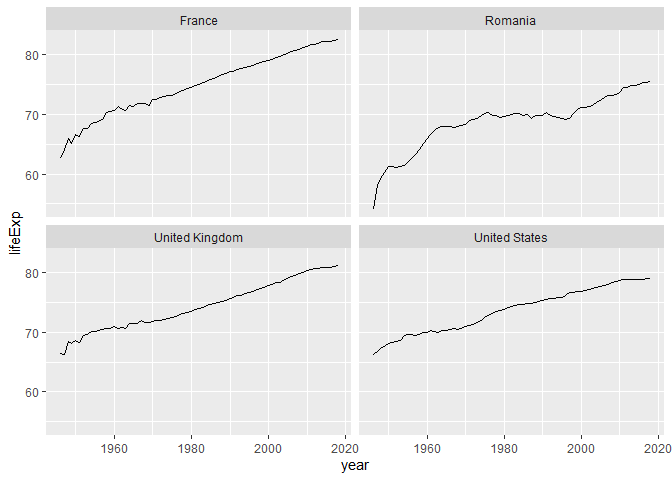

```r
gapminder_all %>%
  mutate(year = as.numeric(year)) %>%
  filter(country %in% c("United States", "France", "United Kingdom", "Romania"),
         year > 1945) %>%
  ggplot(aes(x = year, y = lifeExp)) +
  geom_line() +
  facet_wrap(~country,
             ncol = 2)
```

În figura de mai jos ilustrăm evoluția produsului intern brut pentru statele din Asia de Est după anul 1950. Opțiunea `ncol` descrie numărul de coloane în care vrem să fie împărțit grid-ul de subgrafice iar opțiunea `scales = "free_y"` permite ajustarea scalei pentru axa y pentru fiecare categorie (țară) în parte.

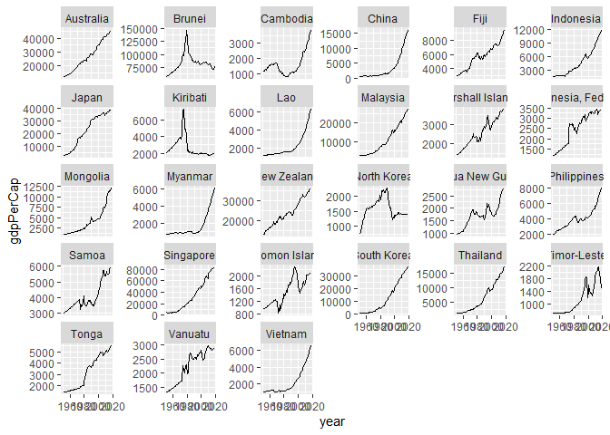

```r
gapminder_all %>%
  mutate(year = as.numeric(year)) %>%
  filter(six_regions == "east_asia_pacific",
         year > 1950) %>%
  ggplot(aes(x = year, y = gdpPerCap)) +
  geom_line()+
  facet_wrap(~country,
             ncol = 6, scales = "free_y")
```

## 4.10 Customizarea graficelor

În această secțiune vom prezenta o serie de metode și tehnici de personalizare/customizare a graficelor atât prin adăugarea de elemente clasice precum titlu, etichetă pentru axe, etc. cât și prin modificarea temelor grafice.

### 4.10.1 Personalizarea elementelor grafice (axe, titlu, etc.)

Titlurile, etichetele axelor și adnotările textuale (pe grafic, axe, obiecte geometrice și legendă) reprezintă un aspect important în crearea unei figuri prin care vrem să transmitem o serie de informații. Pachetul `ggplot2` pune la dispoziție mai multe funcții care permit efectuarea adnotării elementelor grafice fără mare dificultate.

Astfel putem adauga/modifica titlul unui grafic folosind comanda `ggtitle([titlu])`:

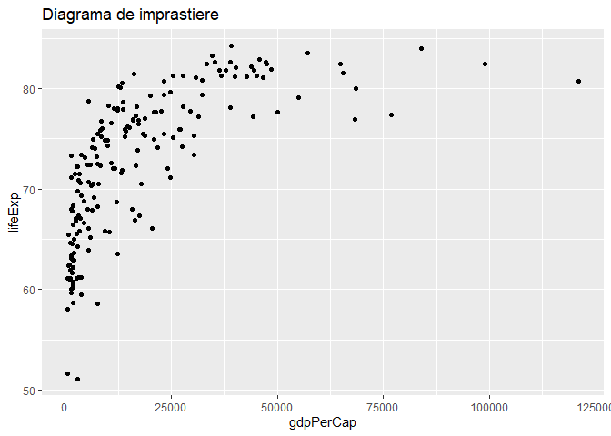

```r
p = ggplot(gapminder_2018, aes(x = gdpPerCap, y = lifeExp))+
  geom_point()

p + ggtitle("Diagrama de imprastiere")
```

sau alternativ putem utiliza funcția `labs(title = [titlu])` care în plus permite adăugarea unui subtitlu (`subtitle`) si a unei surse/credit (`caption`):

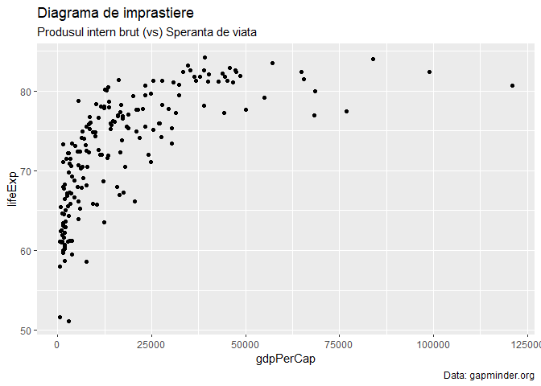

```r
p +
  labs(title = "Diagrama de imprastiere",
       subtitle = "Produsul intern brut (vs) Speranta de viata",
       caption = "Data: gapminder.org")
```

Pentru modificarea etichetelor axelor de coordonate putem folosi sau funcțiile `xlab()` pentru axa $x$ și respectiv `ylab()` pentru axa $y$ sau comanda `labs(x = [eticheta axei x], y = [eticheta axei y])`.

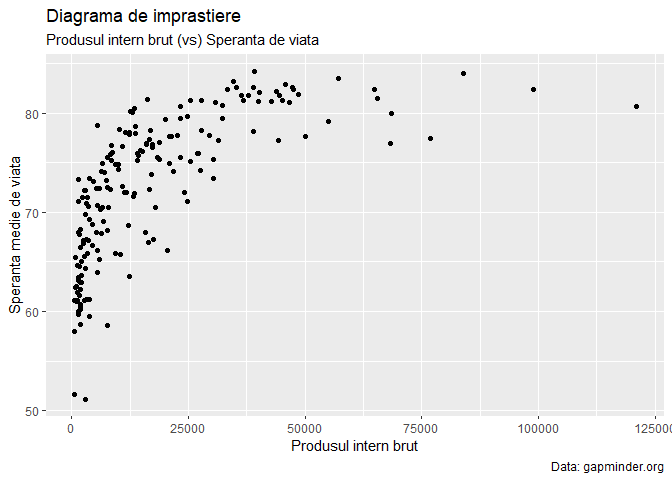

```r
p +
  labs(title = "Diagrama de imprastiere",
       subtitle = "Produsul intern brut (vs) Speranta de viata",
       caption = "Data: gapminder.org",
       x = "Produsul intern brut",
       y = "Speranta medie de viata")
```

De asemenea, am văzut că putem modifica/adăuga nume axelor și prin specificarea acestuia parametrului `name` într-o scală (e.g. `scale_x_continuous`). Atunci când situația impune este recomandat să folosim unităle de măsură ale valorilor variabilelor. Pachetul `scales`, https://scales.r-lib.org/, pune la dispoziție o serie de funcții ajutătoare, de exemplu atunci când unitățile de măsură sunt `$` sau `%`:

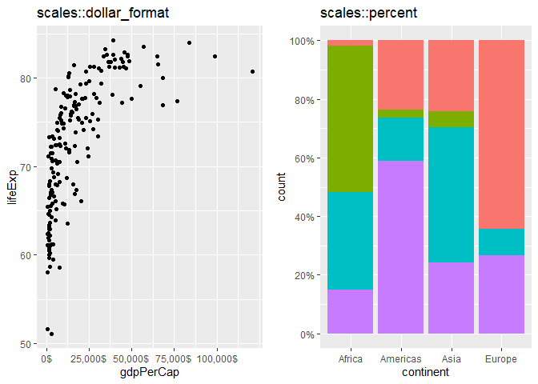

```r
ggplot(gapminder_2018, aes(x = gdpPerCap, y = lifeExp))+
  geom_point() +
  scale_x_continuous(labels = scales::dollar_format(prefix = "", suffix = "$")) +
  ggtitle("scales::dollar_format")

gapminder_2018 %>%
  ggplot(aes(x = continent, fill = wb_income)) +
  geom_bar(position = "fill") +
  scale_y_continuous(breaks = seq(0, 1, by = .2), labels = scales::percent)+
  ggtitle("scales::percent")
```

Totodată se pot întâlni situații în care axa $x$ necesită etichete de lungime mai lungă, conducând astfel la o supraaglomerare a acestora, și în acest caz este recomandată rotirea axelor (`coord_flip()` - poate și ordonarea nivelelor `fct_reorder()`).

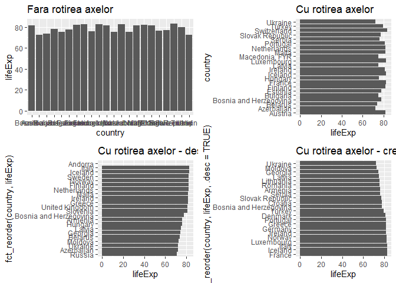

```r
set.seed(1234)

gapminder_2018 %>%
  filter(continent == "Europe") %>%
  sample_frac(0.5) %>%
  ggplot(aes(x = country, y = lifeExp)) +
  geom_bar(stat = "identity") +
  ggtitle("Fara rotirea axelor")

set.seed(1234)

gapminder_2018 %>%
  filter(continent == "Europe") %>%
  sample_frac(0.5) %>%
  ggplot(aes(x = country, y = lifeExp)) +
  geom_bar(stat = "identity") +
  ggtitle("Cu rotirea axelor") +
  coord_flip()
```

Un alt element grafic important în crearea unei figuri este legenda. Am văzut că în `ggplot2` legenda este creată automat atunci când folosim un element estetic precum `colour`, `fill`, `size`, `shape`, etc. După cum am văzut, legendele și axele sunt cele două elemente de ghidaj (*guides*) care pot fi modificate prin intermediul funcțiilor de scalare. Spre deosebire de axe, legendele sunt elemente mai complexe deoarece, pe lângă faptul că pot fi poziționate în diverse locuri, ele pot afișa mai multe estetici simultan (e.g. `colour`, `shape`) provenite de la mai multe straturi geometrice.